# Biometry-01

John

```r
dir <- getwd()
setwd(dir)
```

## Question 1: Barplot Construction

```r
#tinytex::install_tinytex()
file = read.csv("limpets.csv") ## Loading the data set
## tapply() is a function for each factor variable in a vector used to calculate mean
file
```

```
##        SPECIES SEAWATER    O2
## 1     A.scabra     100%  7.16
## 2     A.scabra     100%  6.78
## 3     A.scabra     100% 13.60
## 4     A.scabra     100%  8.93
## 5     A.scabra     100%  8.26
## 6     A.scabra     100% 14.00
## 7     A.scabra     100% 16.10
## 8     A.scabra     100%  9.66
## 9     A.scabra      75%  5.20
## 10    A.scabra      75%  5.20
## 11    A.scabra      75%  7.18
## 12    A.scabra      75%  6.37
## 13    A.scabra      75% 13.20
## 14    A.scabra      75%  8.39
```

[output cut: 34 more lines]

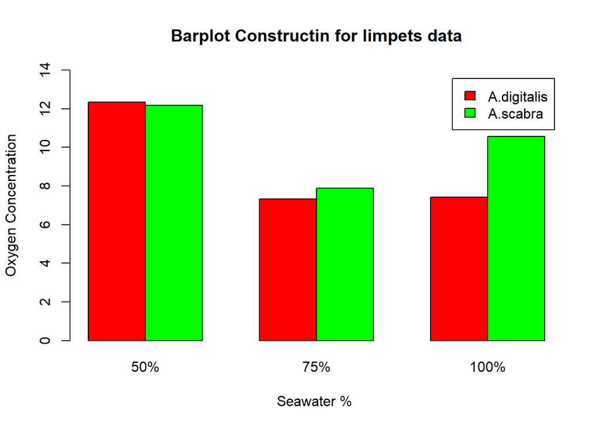

```r
average = with(file,tapply(O2, list(SPECIES,SEAWATER),mean))

column.order= c("50%","75%","100%") # Ordering

barplot(average[,column.order],ylim = c(0,14),beside = T,legend = T,
        main = "Barplot Constructin for limpets data",xlab = "Seawater % ",
        ylab = "Oxygen Concentration", col = c("red","green"))
```

### QUestion 2

```r
data = read.csv("wing_light_tran.csv")
attach(data)
summary(data)
```

```
##         ï..Population wing.translucent
##  stl.city.north:20    Min.   :0.02527
##  stl.city.south:20    1st Qu.:0.24662
##                       Median :0.45808
##                       Mean   :0.51336
##                       3rd Qu.:0.77359
##                       Max.   :0.99635
```

### Ho: Bees in the north side of the city have lighter wings than those in the south side

### Ha: Bees in the north side of the city doesn’t have lighter wings than those in the south side

Step 1: Seperating the data into two categories based on north_side and South_Side

```r
south_side = data[data$ï..Population == "stl.city.south",]
north_side = data[data$ï..Population == "stl.city.north",]
```

## Performing Shipiro Test on South_side and North_side

Here, by performing shipiro test, I can examine if a variable is normally distributed in the dataset. Ho: Normal data Ha: Not normal data

```r
shapiro.test(south_side$wing.translucent)
```

```
##
##  Shapiro-Wilk normality test
##
## data:  south_side$wing.translucent
## W = 0.9111, p-value = 0.06689
```

```r
shapiro.test(north_side$wing.translucent)
```

```
##
##  Shapiro-Wilk normality test
##
## data:  north_side$wing.translucent
## W = 0.94895, p-value = 0.3514
```

Results for the shapiro test indicates that, p value for the north_side is much higher compared to south_side which is 0.3514 and 0.06689 and we accep the NULL hypothesis as the p values are greater than 0.05 and another conclusion is that, the data is normally distributed.

### F-test for variances

Ho: Equal Variences Ho: Unequal Varienes

```r
var.test(north_side$wing.translucent,south_side$wing.translucent)
```

```
##
##  F test to compare two variances
##
## data:  north_side$wing.translucent and south_side$wing.translucent
## F = 0.95964, num df = 19, denom df = 19, p-value = 0.9294
## alternative hypothesis: true ratio of variances is not equal to 1
## 95 percent confidence interval:
##  0.379836 2.424476
## sample estimates:
## ratio of variances
##           0.959637
```

### Choosing type of test

```r
wilcox.test(north_side$wing.translucent,south_side$wing.translucent, paired=T)
```

```
##
##  Wilcoxon signed rank test
##
## data:  north_side$wing.translucent and south_side$wing.translucent
## V = 120, p-value = 0.5958
## alternative hypothesis: true location shift is not equal to 0
```

Here, we accept the NULL hypothesis as the p value is greater that 0.05, that is 0.59..

### Question 3

The paper titled “The Effect of Hurricane Hugo on Six Invertebrate Species in the Luquillo Experimental Forest of Puerto Ricol” used paired t-test in their study as the data is logocally paired. They used same data 40 before and after hurricane. They also performed Chisquare Goodness of Fit Tests to compare observed and spatial distributions and also used G test to compare spatial distributions alone.